# Statistical Inference Project Part I - Simulation

William Matthews

January 16, 2018

### Set working directory

```r
setwd("C:/Users/Bill/Documents/Coursera/JohnsHopkins/Course 6 - Statistical Inference/Week 4")
```

### Load packages

```r
library(ggplot2)
library(dplyr)
```

# 1. Overview:

In this project we will investigate the exponential distribution in R and compare it with the Central Limit Theorem. The mean of the exponential distribution is 1/lambda and the standard deviation is also 1/lambda. For this project we will set lambda = .2 for all of the simulations. We will investigate the distribution of averages of 40 exponentials over 1000 simulations.

# 2. Simulations:

We will simulate the averages of 40 exponential distributions 1000 times to get the sample mean. Set lambda = 0.2. We need to run 1000 simulations of size 40 so set n = 1000 * 40 = 40000.

### Set the seed to ensure reproducability of the results. Simulate 40000 exponential random variables using

### lambda = .2 and store the results in variable sim.

```r
set.seed(1)
lambda <- .2
n <- 40 ## number of exponential variables in sample
sims <- 1000 ## number of simulations
sim <- rexp(n = n * sims, rate = lambda)
```

### Collect simulations in a matrix with each row representing a sample of size 40.

```r
sim_matrix <- matrix(sim, nrow = sims, ncol = n)
```

# 3. Exploratory Data Analysis:

### View the dimensions of the dataset

```r
dim(sim_matrix)
```

```
## [1] 1000   40
```

### View the structure of the dataset

```r
str(sim_matrix)
```

```
##  num [1:1000, 1:40] 3.776 5.908 0.729 0.699 2.18 ...
```

### View range of values

```r
range(sim_matrix)
```

```
## [1] 1.838128e-04 5.791790e+01
```

### Calculate the mean of each sample (row) and assign to variable mean_sim_matrix.

```r
mean_sim_matrix <- apply(sim_matrix, 1, mean)
```

### Sample Mean versus Theoretical Mean:

### Display the mean of the 1000 exponential samples.

```r
mean(mean_sim_matrix)
```

```
## [1] 4.990025
```

### Calculate the theoretical mean.

```r
tmean <- 1/lambda
tmean
```

```
## [1] 5
```

The estimated mean of the 1000 sample exponential means (4.990025) is very close to the theoretical mean of the exponential distribution (1/lambda = 1/.2 = 5). This distribution is centered near the theoretical center of the distribution.

### Sample variance versus theoretical variance:

### Display the variance of the 1000 exponential samples.

```r
var(mean_sim_matrix)
```

```
## [1] 0.6177072
```

### Display the standard deviation of the 1000 exponential samples.

```r
sd(mean_sim_matrix)
```

```
## [1] 0.7859435
```

### Calculate the theoretical variance

```r
tvar <- 1/lambda^2/n
tvar
```

```
## [1] 0.625
```

### Calculate the theoretical standard deviation

```r
tSD <- 1/(lambda*sqrt(n))
tSD
```

```
## [1] 0.7905694
```

The estimated variance of 0.6177072 is is very close to the theoretical variance of the exponential distribution (1/lambda^2/n = 1/.2^2/40 = .625).

# 4. Distribution:

### Plot a histogram of the sample average means

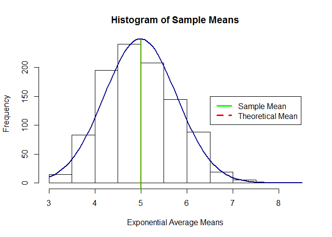

```r
hist(mean_sim_matrix, xlab = 'Exponential Average Means', main = 'Histogram of Sample Means')

# Add vertical line at the mean of the averages
abline(v = mean(mean_sim_matrix), col = "green")

# Add vertical line at the theoretical mean. Add legend to plot.
abline(v = tmean, col = "red")
legend(6.5,150, c('Sample Mean','Theoretical Mean')
       , lwd = c(3,3), lty = c(1,2), col = c("green","red"))

# Show that the distribution is approximately normal by adding a normal distribution curve using the data.
curve(dnorm(x, mean=mean(mean_sim_matrix), sd=sd(mean_sim_matrix))*492, col="darkblue", lwd=2, add=TRUE)
```

### The sample mean appears to be normally distributed.

### Calculate a confidence interval for the simulation.

### Calculate the 95% confidence interval for the sample mean.

```r
std_err <- sd(mean_sim_matrix)/sqrt(n)
lower <- mean(mean_sim_matrix) - 1.96*std_err
upper <- mean(mean_sim_matrix) + 1.96*std_err
c(lower, upper)
```

```
## [1] 4.746459 5.233592
```

### Calculate the 95% confidence interval for the theoretical mean.

```r
tstd_err <- tSD/sqrt(n)
tlower <- tmean - 1.96*tstd_err
tupper <- tmean + 1.96*tstd_err
c(tlower, tupper)
```

```
## [1] 4.755 5.245
```

# 5. Conclusion:

# The sample and theoretical confidence intervals are very close.

# We can say with 95% confidence that the true mean falls between the lower and upper values of the interval.